# Parenting behaviors

Emily

2017-08-29

# 1 Data preprocessing

Preliminaries.

```
## [1] "dplyr"   "langcog" "tidyr"   "ggplot2" "lme4"
```

```
## %+%():    ggplot2, psych
## alpha():  ggplot2, psych
```

Read in participant data.

```r
files <- dir("../production-results/parenting_behaviors_e2/")
attitudes <- data.frame()
behaviors <- data.frame()
subinfo <- data.frame()

for (f in files) {
  jf <- paste("../production-results/parenting_behaviors_e2/",f,sep="")
  jd <- fromJSON(paste(readLines(jf), collapse=""))

  #paq answers
  attitudes_id <- data.frame(sid = as.factor(jd$WorkerId),
               sent = jd$answers$data$sentence[1:24],
               rating = as.numeric(jd$answers$data$rating[1:24]))

  attitudes <- bind_rows(attitudes, attitudes_id)

  #behaviors
  behaviors_id <- data.frame(sid = as.factor(jd$WorkerId),
                sent = jd$answers$data$sentence[25:36],
                rating = as.numeric(jd$answers$data$rating[25:36]))

  behaviors <- bind_rows(behaviors, behaviors_id)

  #demographics
  subinfo_id <- data.frame(sid = as.factor(jd$WorkerId),
                   behave_age = jd$answers$data$behaveAge,
                   children = jd$answers$data$children,
                   youngest = jd$answers$data$childAgeYoung,
                   oldest = jd$answers$data$childAgeOld,
                   ses = jd$answers$data$ladder,
                   gender = jd$answers$data$gender,
                   age = jd$answers$data$age,
                   education = jd$answers$data$education,
                   ethnicity = jd$answers$data$ethnicity,
                   race = as.character(jd$answers$data$race[1]),
                   comments = jd$answers$data$comments)
  subinfo <- bind_rows(subinfo, subinfo_id)
}
```

Read in trial info and questionnaire labels.

```r
labels <- read.csv("sent_forms.csv")
labels$sent <- as.character(labels$sent)
behave <- read.csv("behaviors_e2.csv")
```

Clean up labels.

```r
attitudes$sent <- str_replace_all(as.character(attitudes$sent), "[â‘”“’']", "")
behaviors$sent <- str_replace_all(as.character(behaviors$sent), "[â‘”“’']", "")
```

Make data frames.

```r
dq <- attitudes %>%
  left_join(labels)%>%
  mutate(category_paq = category)%>%
  select(-category)

db <- behaviors%>%
  left_join(behave)%>%
  left_join(subinfo)%>%
  filter(behave_age != "older")%>%
  mutate(category_bev = category)%>%
  select(-category)

#remove items that parents marked as "my child is too young"
db$rating[db$rating == 0] <- NA

#rescore reverse coded items
dq$rating <- as.numeric(dq$rating)
dq$rating[dq$reverse_code == 1] <- 6 - dq$rating[dq$reverse_code == 1]
```

Get means by category.

```r
atts <- dq %>%
  group_by(sid, category_paq) %>%
  summarise(rating_paq = mean(rating))

bevs <- db %>%
  group_by(sid, category_bev) %>%
  summarise(rating_bev = mean(rating))

all <- atts %>%
  left_join(bevs)%>%
  left_join(subinfo)%>%
  filter(!children == "0")

all$category_paq <- str_replace(all$category_paq, "AA", "AA_paq")
all$category_paq <- str_replace(all$category_paq, "EL", "EL_paq")
all$category_paq <- str_replace(all$category_paq, "RR", "RR_paq")

all$category_bev <- str_replace(all$category_bev, "AA", "AA_behave")
all$category_bev <- str_replace(all$category_bev, "EL", "EL_behave")
all$category_bev <- str_replace(all$category_bev, "RR", "RR_behave")
```

# 2 Demographics

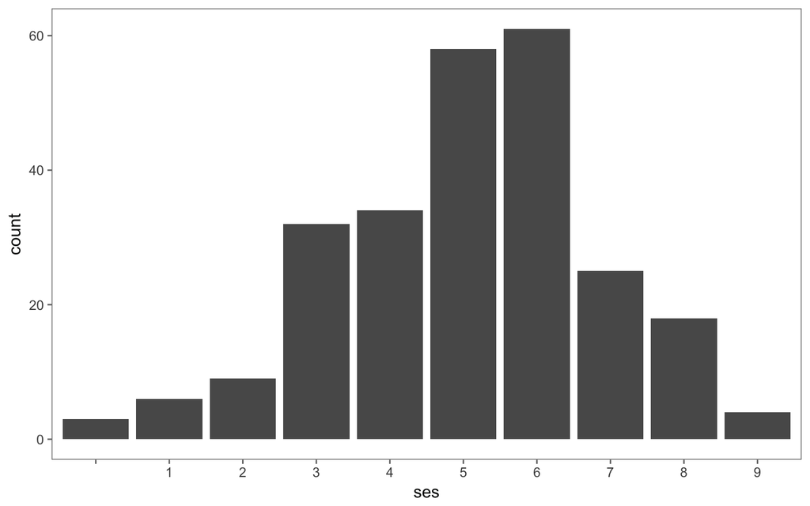

```r
subinfo$education <- factor(subinfo$education,
                            levels = c("highSchool","someCollege","4year","someGrad","Grad"))

qplot(ses, data=subinfo)
```

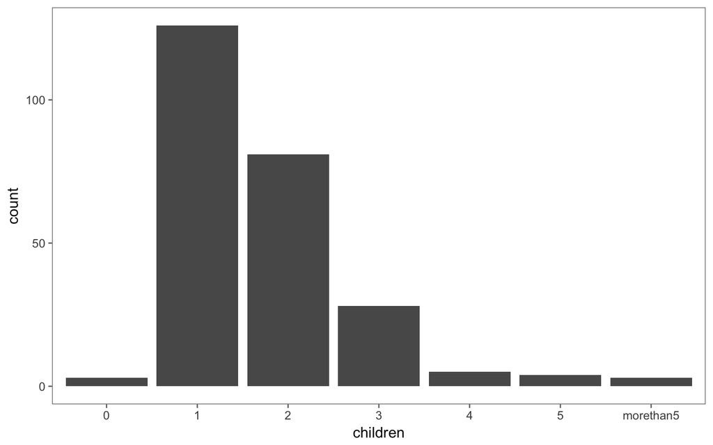

```r
qplot(children, data=subinfo)
```

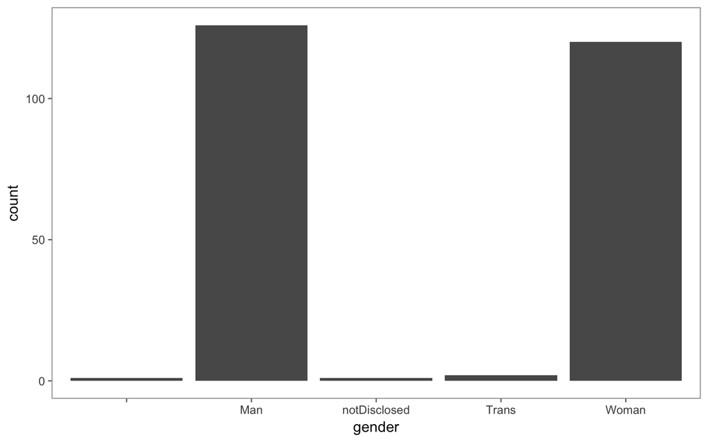

```r
qplot(gender, data=subinfo)
```

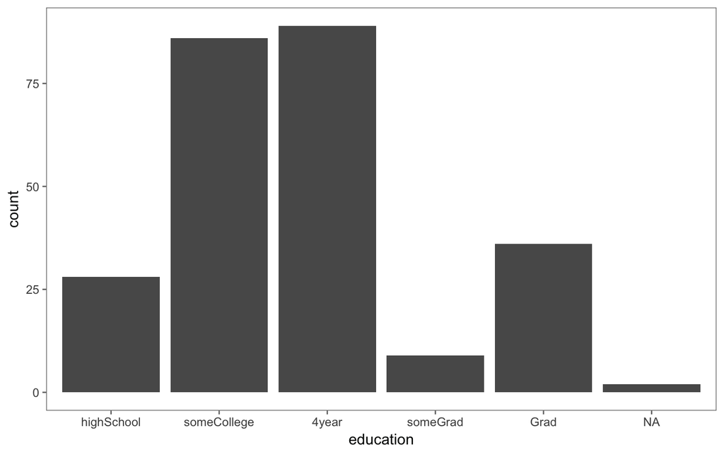

```r
qplot(education, data=subinfo)
```

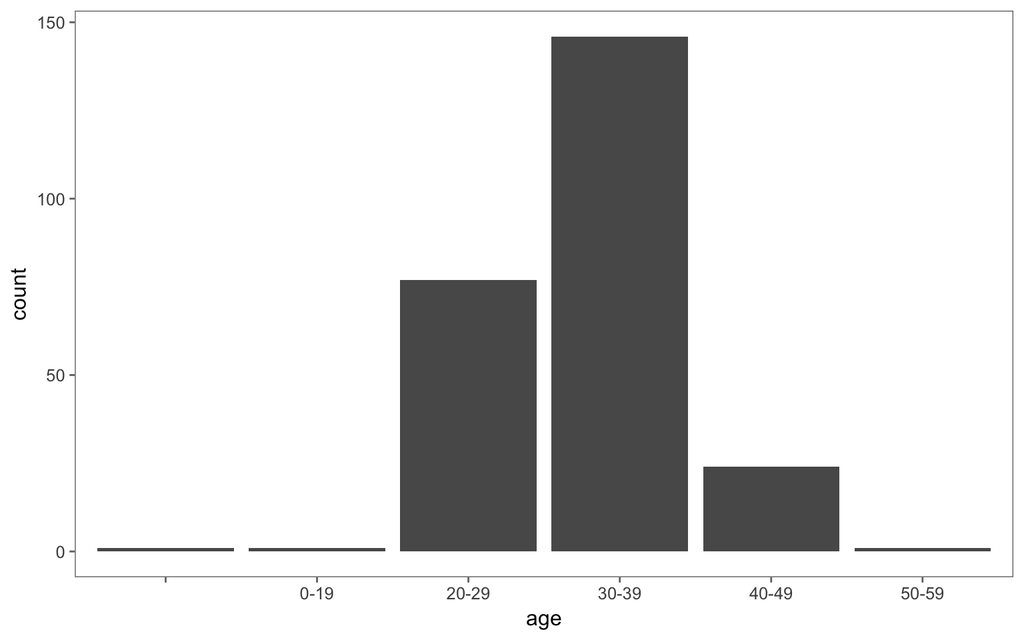

```r
qplot(age, data=subinfo)
```

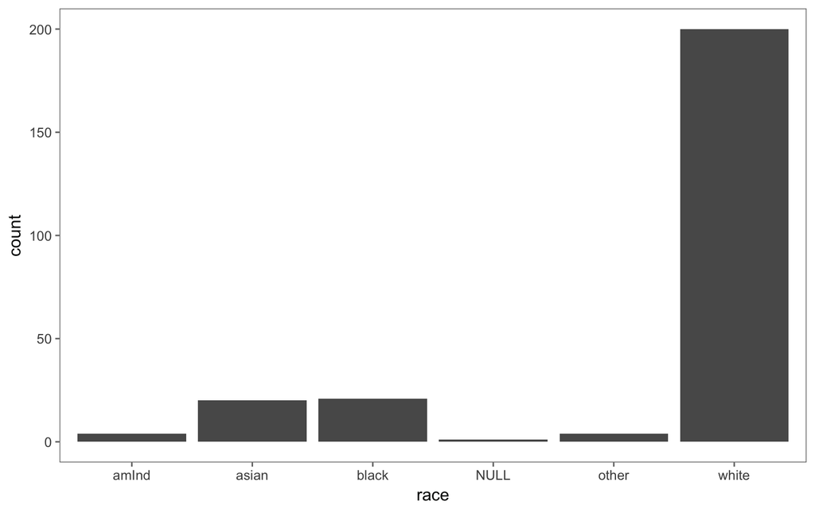

```r
qplot(race, data=subinfo)
```

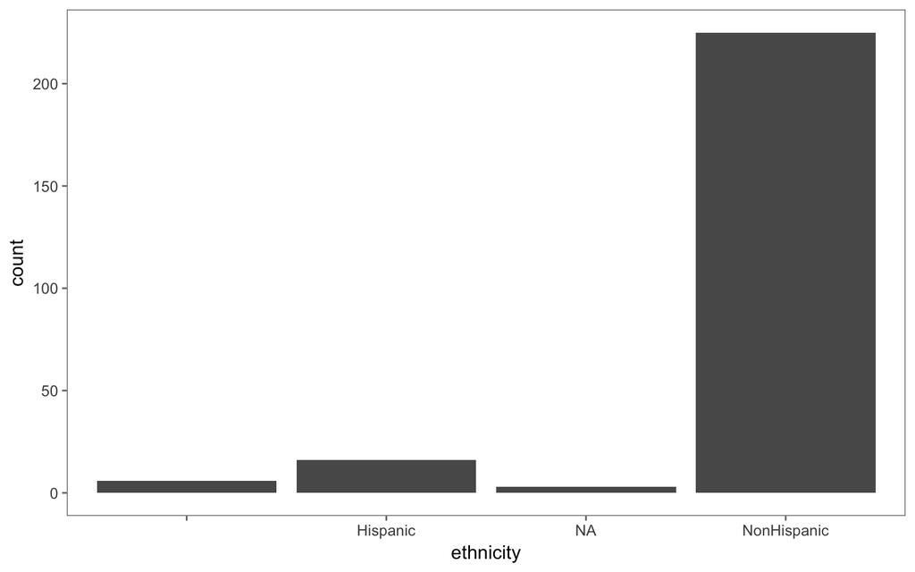

```r
qplot(ethnicity, data=subinfo)
```

# 3 PAQ

Get mean ratings for sentences.

```r
ms <- dq %>%
  group_by(category_paq, short_sent, reverse_code) %>%
  multi_boot_standard(col = "rating", na.rm = TRUE) %>%
  arrange(category_paq, desc(mean))

ms$short_sent_ord <- factor(ms$short_sent,
                             levels = ms$short_sent)


#for comparison with CDM data
beh <- ms
save(beh, file = "beh.RData")
```

Plot responses to individual questionnaire items.

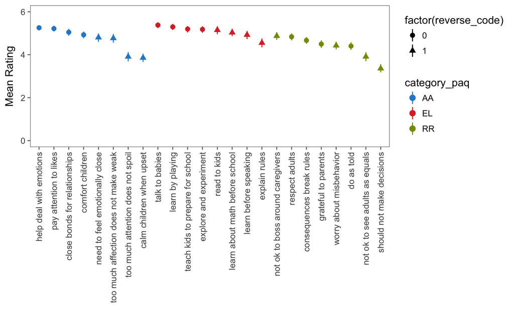

```r
qplot(short_sent_ord, mean, col = category_paq,
      ymin = ci_lower, ymax = ci_upper, pch = factor(reverse_code),
      geom = "pointrange",
      data = ms) +
  theme(axis.text.x = element_text(angle = 90, hjust = 1, vjust = .5)) +
  xlab("") +
  ylab("Mean Rating") +
  ylim(c(0,6)) +
  scale_colour_solarized()
```

Plot mean subscale scores.

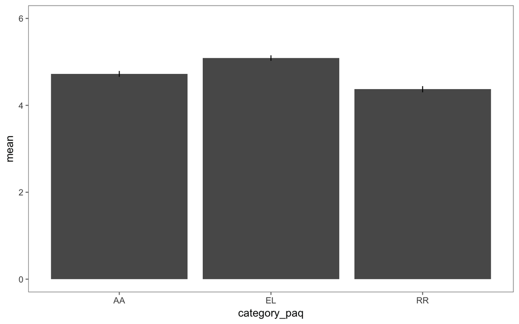

```r
atts_m <- dq %>%
  group_by(category_paq) %>%
  multi_boot_standard(col = "rating", na.rm = TRUE) %>%
  arrange(category_paq, desc(mean))

ggplot(atts_m, aes(x = category_paq, y = mean)) +
  geom_bar(stat="identity") +
  geom_linerange(aes(ymin = ci_lower, ymax = ci_upper),
             position = position_dodge(width = .9))+
  ylim(c(0,6))
```

# 4 Behaviors

Get mean ratings for behaviors.

```r
ms_b <- db %>%
  group_by(category_bev, short_sent) %>%
  multi_boot_standard(col = "rating", na.rm = TRUE) %>%
  arrange(category_bev, desc(mean))

ms_b$short_sent_ord <- factor(ms_b$short_sent,
                             levels = ms_b$short_sent)
```

Recode variables for plotting.

```r
bev <- behaviors %>%
  left_join(behave)%>%
  filter(rating != 0)%>%
  group_by(category)

bev$rating[bev$rating=="1"] <- "Never"
bev$rating[bev$rating=="2"] <- "Almost never"
bev$rating[bev$rating=="3"] <- "Occasionally"
bev$rating[bev$rating=="4"] <- "Once or twice per week"
bev$rating[bev$rating=="5"] <- "Most days"
bev$rating[bev$rating=="6"] <- "Multiple times ever day"

bev$rating <- factor(bev$rating, levels = c("My child is too young", "Never", "Almost never","Occasionally","Once or twice per week","Most days","Multiple times ever day"))

bev$short_sent <- factor(bev$short_sent, levels = c("read","practice numbers and letters","make observations", "educational programming","talk about feelings","spend time cuddling","sleep in the same bed","hug and kiss","talk sternly","give time out or punishments","talk about setting limits","help with chores"))

subinfo$behave_age[subinfo$behave_age == "0-6"] <- "0-6 months"
subinfo$behave_age[subinfo$behave_age == "7-12"] <- "7-12 months"

subinfo$behave_age <- factor(subinfo$behave_age, levels = c("0-6 months", "7-12 months", "1-1.5","1.5-2","2-2.5","2.5-3","3-3.5","3.5-4", "4-4.5","4.5-5", "older"))
```

Plot mean frequency of individual behavior items. This treats frequency as a continuous variable which it really isn’t- is there a better way or does this seem okay?

Parents were asked to answer questions about their youngest child. How old is their youngest child?

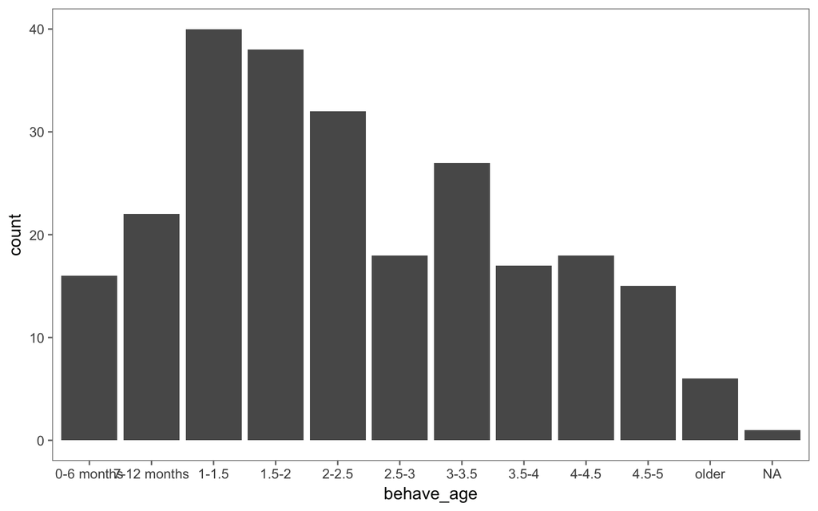

```r
qplot(behave_age, data=subinfo)
```

How frequent were individual behaviors?

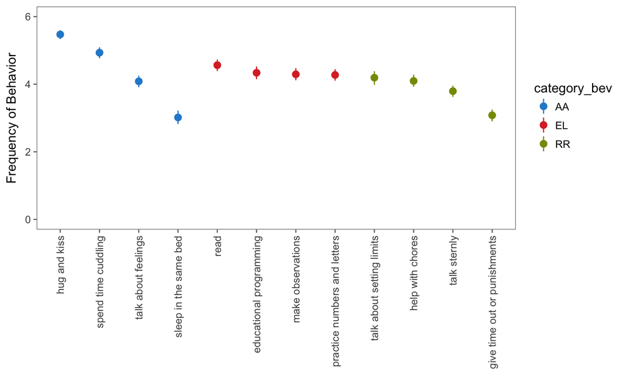

```r
qplot(short_sent_ord, mean, col = category_bev,
      ymin = ci_lower, ymax = ci_upper,
      geom = "pointrange",
      data = ms_b) +
  theme(axis.text.x = element_text(angle = 90, hjust = 1, vjust = .5)) +
  xlab("") +
  ylab("Frequency of Behavior") +
  ylim(c(0,6)) +
  scale_colour_solarized()
```

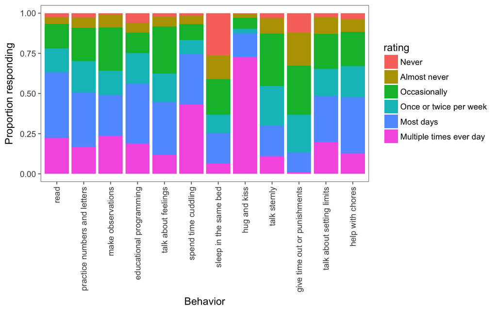

```r
ggplot(bev, aes(short_sent, fill = rating, shape = category)) +
  geom_bar(position = "fill")+
  theme(axis.text.x = element_text(angle = 90, hjust = 1, vjust = .5)) +
  xlab("Behavior") +
  ylab("Proportion responding")
```

## 4.1 Reliability

Are behaviors within a category correlated with each other? This is relevant if we choose to use mean scores within these categories for subsequent analyses.

Rules and Respect

```r
wide.bev <- db %>%
  filter(category_bev == "RR") %>%
  select(sid, short_sent, rating) %>%
  spread(short_sent, rating)
alpha.rr <- as.matrix(select(wide.bev, -sid))
psych::alpha(x = alpha.rr)
```

```
##
## Reliability analysis
## Call: psych::alpha(x = alpha.rr)
##
##   raw_alpha std.alpha G6(smc) average_r S/N  ase mean sd
##       0.71      0.71    0.66      0.38 2.5 0.03  3.7  1
##
##  lower alpha upper     95% confidence boundaries
## 0.65 0.71 0.77
##
##  Reliability if an item is dropped:
##                              raw_alpha std.alpha G6(smc) average_r S/N
## give time out or punishments      0.65      0.65    0.57      0.39 1.9
## help with chores                  0.72      0.72    0.64      0.46 2.6
## talk about setting limits         0.62      0.62    0.55      0.36 1.7
## talk sternly                      0.59      0.59    0.49      0.32 1.4
##                              alpha se
## give time out or punishments    0.039
## help with chores                0.031
## talk about setting limits       0.043
## talk sternly                    0.046
##
##  Item statistics
##                                n raw.r std.r r.cor r.drop mean  sd
## give time out or punishments 197  0.73  0.73  0.59   0.49  3.1 1.2
## help with chores             206  0.68  0.65  0.44   0.38  4.1 1.3
## talk about setting limits    202  0.78  0.76  0.64   0.54  4.2 1.4
## talk sternly                 224  0.81  0.79  0.72   0.59  3.8 1.3
##
## Non missing response frequency for each item
##                                 1    2    3    4    5    6 miss
## give time out or punishments 0.12 0.20 0.31 0.24 0.12 0.01 0.19
## help with chores             0.04 0.08 0.21 0.20 0.34 0.13 0.16
## talk about setting limits    0.02 0.10 0.21 0.17 0.30 0.19 0.17
## talk sternly                 0.03 0.10 0.33 0.25 0.19 0.11 0.08
```

Affection and Attachment

```r
wide.bev <- db %>%
  filter(category_bev == "AA") %>%
  select(sid, short_sent, rating) %>%
  spread(short_sent, rating)
alpha.aa <- as.matrix(select(wide.bev, -sid))
psych::alpha(x = alpha.aa)
```

```
##
## Reliability analysis
## Call: psych::alpha(x = alpha.aa)
##
##   raw_alpha std.alpha G6(smc) average_r S/N   ase mean   sd
##       0.55      0.59     0.6      0.27 1.5 0.048  4.4 0.87
##
##  lower alpha upper     95% confidence boundaries
## 0.46 0.55 0.65
##
##  Reliability if an item is dropped:
##                       raw_alpha std.alpha G6(smc) average_r  S/N alpha se
## hug and kiss               0.40      0.42    0.34      0.19 0.71    0.067
## sleep in the same bed      0.68      0.69    0.65      0.42 2.18    0.036
## spend time cuddling        0.28      0.32    0.26      0.14 0.47    0.080
## talk about feelings        0.53      0.58    0.59      0.32 1.40    0.055
##
##  Item statistics
##                         n raw.r std.r r.cor r.drop mean  sd
## hug and kiss          243  0.69  0.75  0.72   0.47  5.5 1.1
## sleep in the same bed 238  0.61  0.50  0.19   0.15  3.0 1.6
## spend time cuddling   240  0.79  0.82  0.81   0.56  4.9 1.3
## talk about feelings   199  0.56  0.61  0.36   0.27  4.1 1.2
##
## Non missing response frequency for each item
##                          1    2    3    4    5    6 miss
## hug and kiss          0.00 0.02 0.07 0.03 0.14 0.73 0.00
## sleep in the same bed 0.26 0.15 0.22 0.12 0.19 0.06 0.02
## spend time cuddling   0.02 0.05 0.09 0.09 0.31 0.44 0.02
## talk about feelings   0.02 0.06 0.30 0.18 0.33 0.12 0.18
```

Early Learning

```r
wide.bev <- db %>%
  filter(category_bev == "EL") %>%
  select(sid, short_sent, rating) %>%
  spread(short_sent, rating)
alpha.el <- as.matrix(select(wide.bev, -sid))
psych::alpha(x = alpha.el)
```

```
##
## Reliability analysis
## Call: psych::alpha(x = alpha.el)
##
##   raw_alpha std.alpha G6(smc) average_r S/N   ase mean sd
##       0.69       0.7    0.65      0.37 2.3 0.032  4.3  1
##
##  lower alpha upper     95% confidence boundaries
## 0.63 0.69 0.76
##
##  Reliability if an item is dropped:
##                              raw_alpha std.alpha G6(smc) average_r S/N
## educational programming           0.69      0.70    0.61      0.43 2.3
## make observations                 0.61      0.61    0.53      0.35 1.6
## practice numbers and letters      0.60      0.60    0.51      0.33 1.5
## read                              0.62      0.62    0.52      0.35 1.6
##                              alpha se
## educational programming         0.034
## make observations               0.044
## practice numbers and letters    0.045
## read                            0.042
##
##  Item statistics
##                                n raw.r std.r r.cor r.drop mean  sd
## educational programming      224  0.70  0.66  0.46   0.38  4.3 1.4
## make observations            218  0.76  0.74  0.61   0.51  4.3 1.3
## practice numbers and letters 215  0.76  0.76  0.64   0.53  4.3 1.3
## read                         236  0.75  0.74  0.62   0.50  4.6 1.2
##
## Non missing response frequency for each item
##                                 1    2    3    4    5    6 miss
## educational programming      0.06 0.06 0.12 0.19 0.38 0.19 0.08
## make observations            0.00 0.08 0.26 0.16 0.26 0.24 0.11
## practice numbers and letters 0.02 0.06 0.21 0.20 0.34 0.17 0.12
## read                         0.03 0.04 0.14 0.15 0.41 0.23 0.03
```

Early Learning and Rules and Respect items hang together pretty well (alphas = .70) but Affection and Attachment items are not as great (alpha = .55). Dropping “sleep in the same bed” would help. Also, “hug and kiss” is close to ceiling with most people reporting “multiple times every day.”

## 4.2 Demographic predictors of behaviors

Education

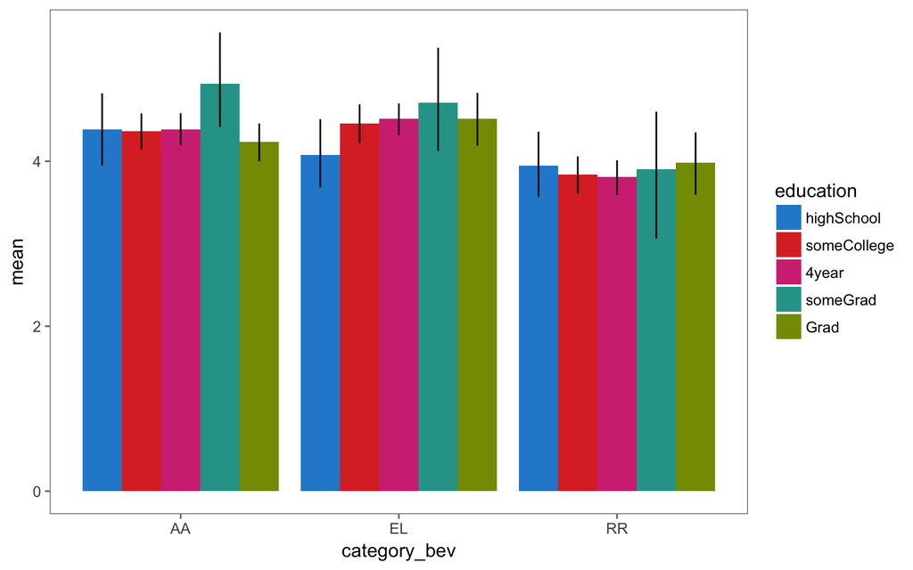

```r
mf <- bevs %>%
  left_join(subinfo)%>%
  filter(education != "") %>%
  group_by(education, category_bev) %>%
  multi_boot_standard(col = "rating_bev", na.rm = TRUE)

ggplot(mf, aes(category_bev, mean, fill=education)) +
  geom_bar(stat="identity", position = "dodge") +
  geom_linerange(aes(ymin = ci_lower, ymax = ci_upper),
             position = position_dodge(width = .9)) +
  scale_fill_solarized()
```

Gender

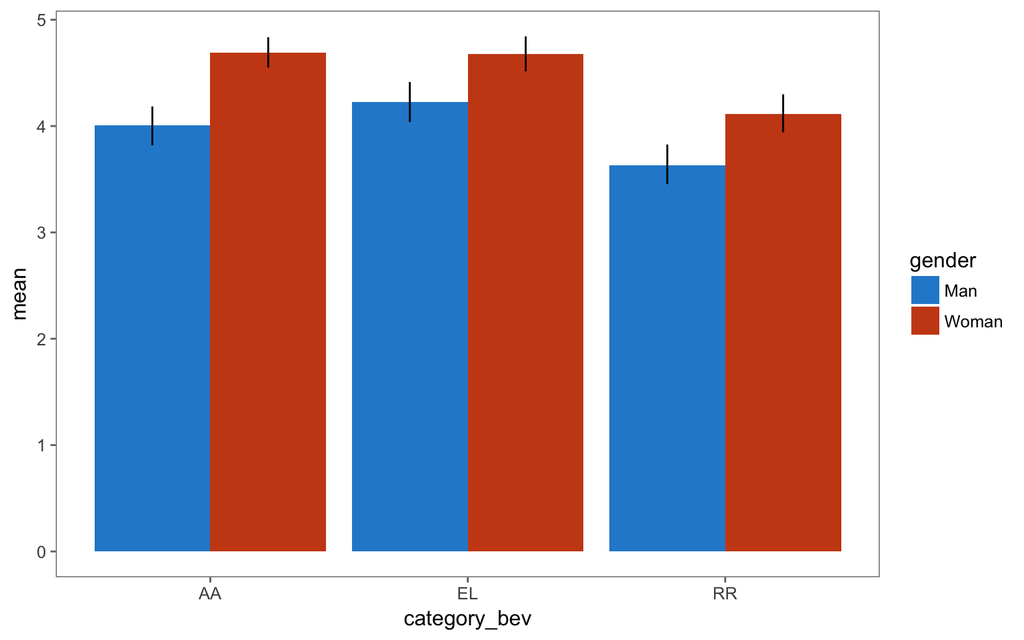

```r
mf <- bevs %>%
  left_join(subinfo)%>%
  filter(gender == "Man" || gender == "Woman") %>%
  group_by(gender, category_bev) %>%
  multi_boot_standard(col = "rating_bev", na.rm = TRUE)

ggplot(mf, aes(category_bev, mean, fill=gender)) +
  geom_bar(stat="identity", position = "dodge") +
  geom_linerange(aes(ymin = ci_lower, ymax = ci_upper),
             position = position_dodge(width = .9)) +
  scale_fill_solarized()
```

Moms are engaging with their children more overall.

Age of child

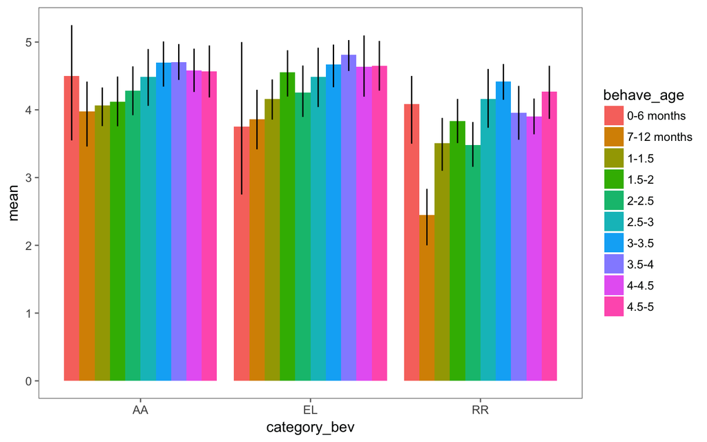

```r
mf <- bevs %>%
  left_join(subinfo)%>%
  filter(behave_age != "") %>%
  group_by(behave_age, category_bev) %>%
  multi_boot_standard(col = "rating_bev", na.rm = TRUE)

ggplot(mf, aes(category_bev, mean, fill=behave_age)) +
  geom_bar(stat="identity", position = "dodge") +
  geom_linerange(aes(ymin = ci_lower, ymax = ci_upper),
             position = position_dodge(width = .9))
```

More behaviors are possible as kids get older.

Race

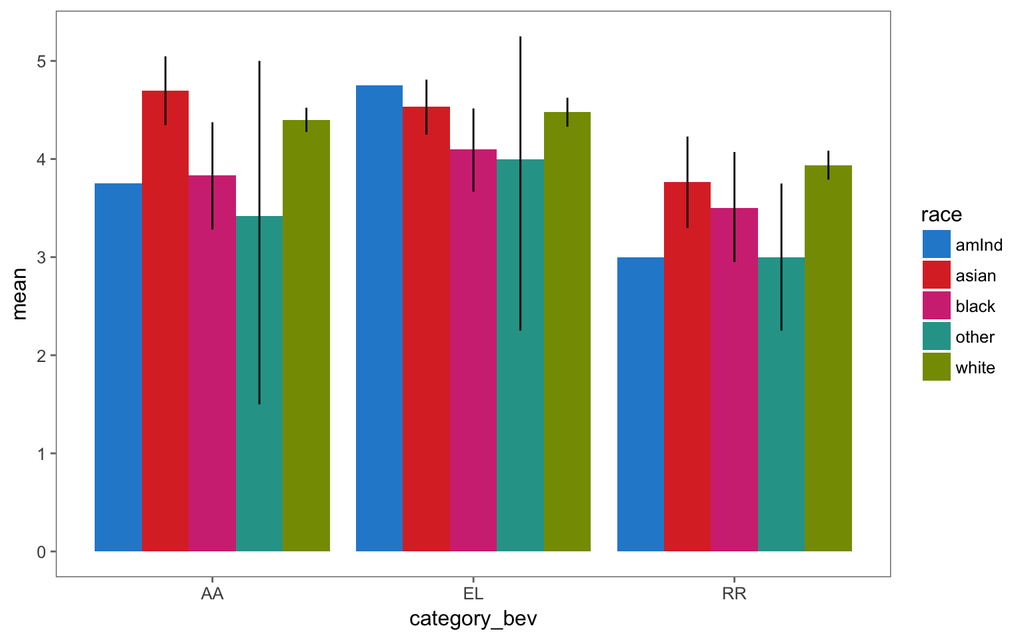

```r
mf <- bevs %>%
  left_join(subinfo)%>%
  filter(race != "NULL") %>%
  group_by(race, category_bev) %>%
  multi_boot_standard(col = "rating_bev", na.rm = TRUE)

ggplot(mf, aes(category_bev, mean, fill=race)) +
  geom_bar(stat="identity", position = "dodge") +
  geom_linerange(aes(ymin = ci_lower, ymax = ci_upper),
             position = position_dodge(width = .9)) +
  scale_fill_solarized()
```

SES

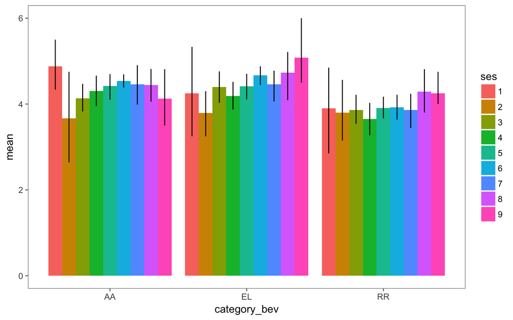

```r
mf <- bevs %>%
  left_join(subinfo)%>%
  filter(ses != "") %>%
  group_by(ses, category_bev) %>%
  multi_boot_standard(col = "rating_bev", na.rm = TRUE)

ggplot(mf, aes(category_bev, mean, fill=ses)) +
  geom_bar(stat="identity", position = "dodge") +
  geom_linerange(aes(ymin = ci_lower, ymax = ci_upper),
             position = position_dodge(width = .9))
```

# 5 Attitudes and Behaviors

This might not be the best plot- I’d rather see the individual behaviors, but not sure the best way to present this without overwhelming.

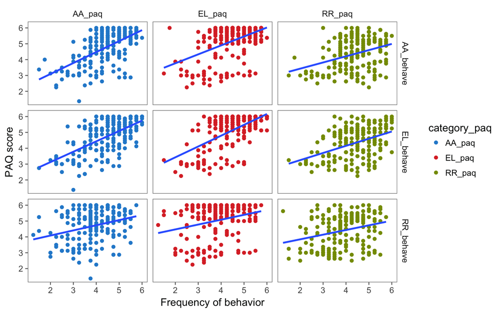

```r
ggplot(filter(all, !is.na(category_bev)), aes(x= rating_bev, y = rating_paq)) +
  facet_grid(category_bev ~category_paq) +
  geom_point(aes(color = category_paq)) +
  xlab("Frequency of behavior") +
  ylab("PAQ score") +
  scale_colour_solarized()+
  geom_smooth(method="lm", se=FALSE)
```

## 5.1 Stats

Set up dataframes for analyses.

```r
d <- db %>%
  left_join(atts)%>%
  left_join(subinfo)%>%
  filter(!is.na(rating))%>%
  filter(children != 0)%>%
  filter(behave_age != "older")%>%
  filter(behave_age != "")%>%
  select(sid, short_sent, rating, category_paq, category_bev, rating_paq, behave_age)%>%
  spread(category_paq, rating_paq)

d$behave_age <- as.character(d$behave_age)

d$behave_age[d$behave_age == "0-6 months"] <- 1
d$behave_age[d$behave_age == "7-12 months"] <- 7
d$behave_age[d$behave_age == "1-1.5"] <- 13
d$behave_age[d$behave_age == "1.5-2"] <- 19
d$behave_age[d$behave_age == "2-2.5"] <- 25
d$behave_age[d$behave_age == "2.5-3"] <- 31
d$behave_age[d$behave_age == "3-3.5"] <- 37
d$behave_age[d$behave_age == "3.5-4"] <- 43
d$behave_age[d$behave_age == "4-4.5"] <- 49
d$behave_age[d$behave_age == "4.5-5"] <- 55

d$behave_age <- as.numeric(d$behave_age)

d<- d%>%
  mutate(child_age = behave_age)%>%
  select(-behave_age)%>%
  mutate(rating_bin = rating)

d$rating_bin[d$rating %in% 1:4] <- "low"
d$rating_bin[d$rating %in% 5:6] <- "high"

d_aa <- d%>%
  filter(category_bev == "AA")%>%
  filter(!is.na(rating), !is.na(rating_bin))

d_el <- d%>%
  filter(category_bev == "EL")%>%
  filter(!is.na(rating),!is.na(rating_bin))

d_rr <- d%>%
  filter(category_bev == "RR")%>%
  filter(!is.na(rating),!is.na(rating_bin))

d_aa$rating_bin <- as.factor(d_aa$rating_bin)
d_el$rating_bin <- as.factor(d_el$rating_bin)
d_rr$rating_bin <- as.factor(d_rr$rating_bin)
```

Plot

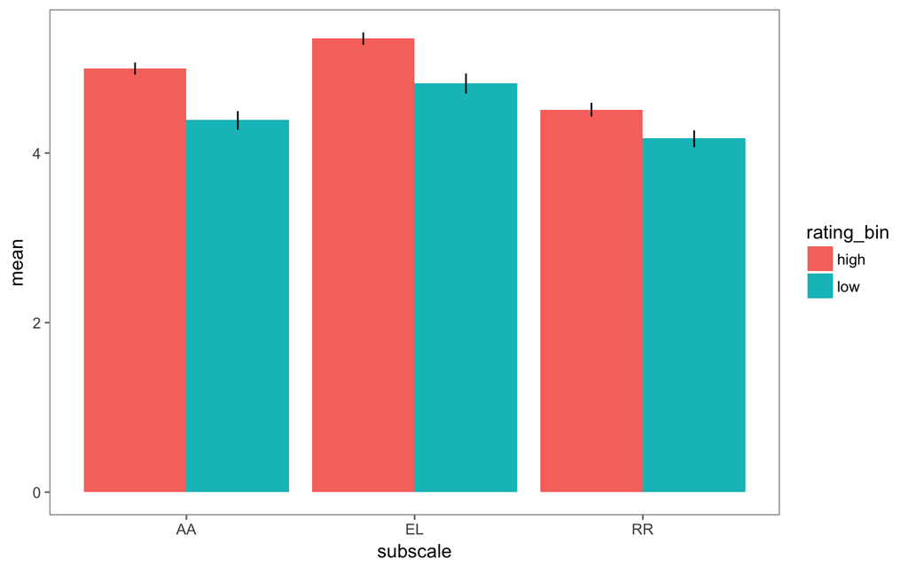

```r
d_plot_aa <- d_aa%>%
  gather("subscale", "rating_paq", AA:RR)%>%
  group_by(subscale, rating_bin) %>%
  multi_boot_standard(col = "rating_paq", na.rm = TRUE)

ggplot(d_plot_aa, aes(subscale, mean, fill=rating_bin)) +
  geom_bar(stat="identity", position = "dodge") +
  geom_linerange(aes(ymin = ci_lower, ymax = ci_upper),
             position = position_dodge(width = .9))
```

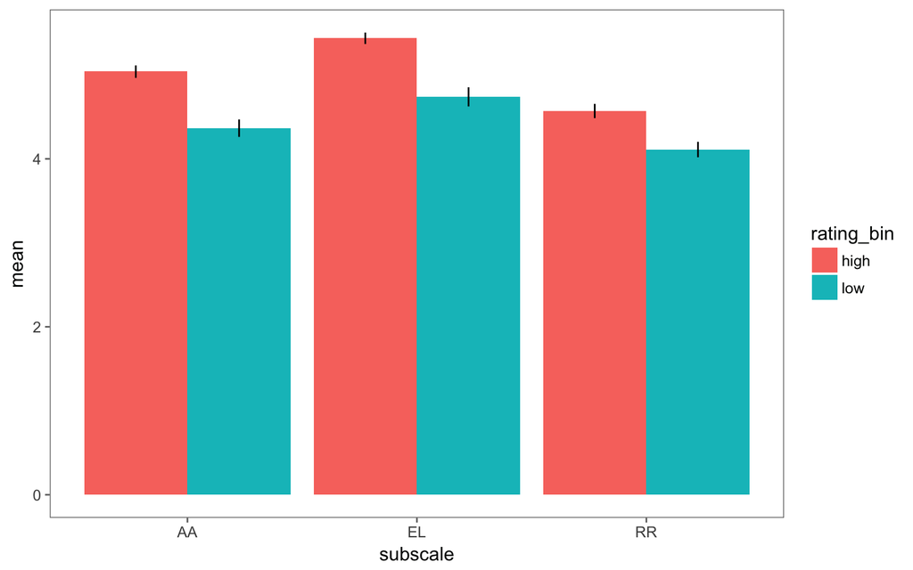

```r
d_plot_el <- d_el%>%
  gather("subscale", "rating_paq", AA:RR)%>%
  group_by(subscale, rating_bin) %>%
  multi_boot_standard(col = "rating_paq", na.rm = TRUE)

ggplot(d_plot_el, aes(subscale, mean, fill=rating_bin)) +
  geom_bar(stat="identity", position = "dodge") +
  geom_linerange(aes(ymin = ci_lower, ymax = ci_upper),
             position = position_dodge(width = .9))
```

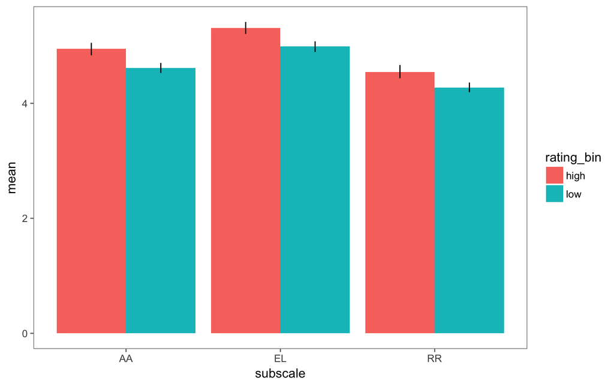

```r
d_plot_rr <- d_rr%>%
  gather("subscale", "rating_paq", AA:RR)%>%
  group_by(subscale, rating_bin) %>%
  multi_boot_standard(col = "rating_paq", na.rm = TRUE)

ggplot(d_plot_rr, aes(subscale, mean, fill=rating_bin)) +
  geom_bar(stat="identity", position = "dodge") +
  geom_linerange(aes(ymin = ci_lower, ymax = ci_upper),
             position = position_dodge(width = .9))
```

Separate models for each category of behavior. Do PAQ subscale scores predict the frequency of parenting behaviors?

### 5.1.1 Affection and Attachment

```r
model <- summary(glmer(rating_bin ~ AA + RR + EL + child_age +
                (1|sid) +
                (1|short_sent), #behavior item
              data = d_aa,
              family = "binomial"))
model
```

```
## Generalized linear mixed model fit by maximum likelihood (Laplace
##   Approximation) [glmerMod]
##  Family: binomial  ( logit )
## Formula:
## rating_bin ~ AA + RR + EL + child_age + (1 | sid) + (1 | short_sent)
##    Data: d_aa
##
##      AIC      BIC   logLik deviance df.resid
##    777.2    809.9   -381.6    763.2      785
##
## Scaled residuals:
##     Min      1Q  Median      3Q     Max
## -5.6545 -0.4463 -0.1969  0.5350  3.0713
##
## Random effects:
##  Groups     Name        Variance Std.Dev.
##  sid        (Intercept) 1.262    1.123
##  short_sent (Intercept) 2.678    1.636
## Number of obs: 792, groups:  sid, 205; short_sent, 4
##
## Fixed effects:
##             Estimate Std. Error z value Pr(>|z|)
## (Intercept)  4.90594    1.14315   4.292 1.77e-05 ***
## AA          -0.97914    0.22194  -4.412 1.03e-05 ***
## RR           0.01263    0.15873   0.080    0.937
## EL          -0.10770    0.21141  -0.509    0.610
## child_age   -0.01160    0.00986  -1.176    0.240
## ---
## Signif. codes:  0 '***' 0.001 '**' 0.01 '*' 0.05 '.' 0.1 ' ' 1
##
## Correlation of Fixed Effects:
##           (Intr) AA     RR     EL
## AA        -0.191
## RR        -0.179 -0.100
## EL        -0.172 -0.673 -0.298
## child_age -0.143 -0.082 -0.207  0.095
```

### 5.1.2 Early Learning

```r
#for EL behaviors
model <- summary(glmer(rating_bin ~ AA + RR + EL + child_age +
                (1|sid) +
                (1|short_sent), #behavior item
              data = d_el,
              family = "binomial"))
model
```

[output not shown]

### 5.1.3 Rules and Respect

```r
model <- summary(glmer(rating_bin ~ AA + RR + EL + child_age +
                (1|sid) +
                (1|short_sent), #behavior item
              data = d_rr,
              family = "binomial"))
model
```

```
## Generalized linear mixed model fit by maximum likelihood (Laplace
##   Approximation) [glmerMod]
##  Family: binomial  ( logit )
## Formula:
## rating_bin ~ AA + RR + EL + child_age + (1 | sid) + (1 | short_sent)
##    Data: d_rr
##
##      AIC      BIC   logLik deviance df.resid
##    883.9    916.4   -434.9    869.9      760
##
## Scaled residuals:
##     Min      1Q  Median      3Q     Max
## -4.6250 -0.6407  0.3210  0.5723  1.8340
##
## Random effects:
##  Groups     Name        Variance Std.Dev.
##  sid        (Intercept) 1.847    1.3590
##  short_sent (Intercept) 0.964    0.9819
## Number of obs: 767, groups:  sid, 204; short_sent, 4
##
## Fixed effects:
##             Estimate Std. Error z value Pr(>|z|)
## (Intercept)  4.19556    0.98437   4.262 2.02e-05 ***
## AA          -0.22895    0.22913  -0.999   0.3177
## RR          -0.16977    0.16965  -1.001   0.3170
## EL          -0.16866    0.23191  -0.727   0.4671
## child_age   -0.01906    0.01052  -1.812   0.0701 .
## ---
## Signif. codes:  0 '***' 0.001 '**' 0.01 '*' 0.05 '.' 0.1 ' ' 1
##
## Correlation of Fixed Effects:
##           (Intr) AA     RR     EL
## AA        -0.131
## RR        -0.251 -0.121
## EL        -0.259 -0.708 -0.266
## child_age -0.191 -0.105 -0.167  0.084
```

# 6 Conclusions